# Two HRS Core cognitive classification methods informed by HRS/HCAP

Rich Jones and Doug Tommet for HRS/HCAP Working Group

2026-10-17

## Contents

- Three classification algorithms: HRS/HCAP, Core, PMM
- How the Core algorithm and the PMM work
- Agreement of the Core algorithm and the PMM with the HRS/HCAP Algorithm
- Summary

## Key terms: three algorithms

[output not shown]

## HRS/HCAP Algorithm

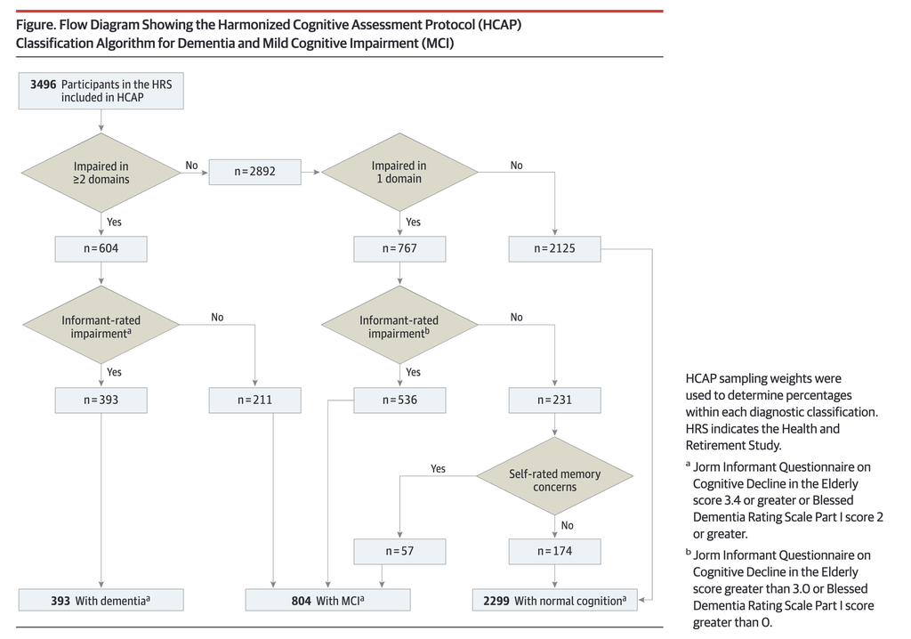

Source: Manly et al. (2022), JAMA Neurology, 79(12), 1242-1249.

## Core algorithm

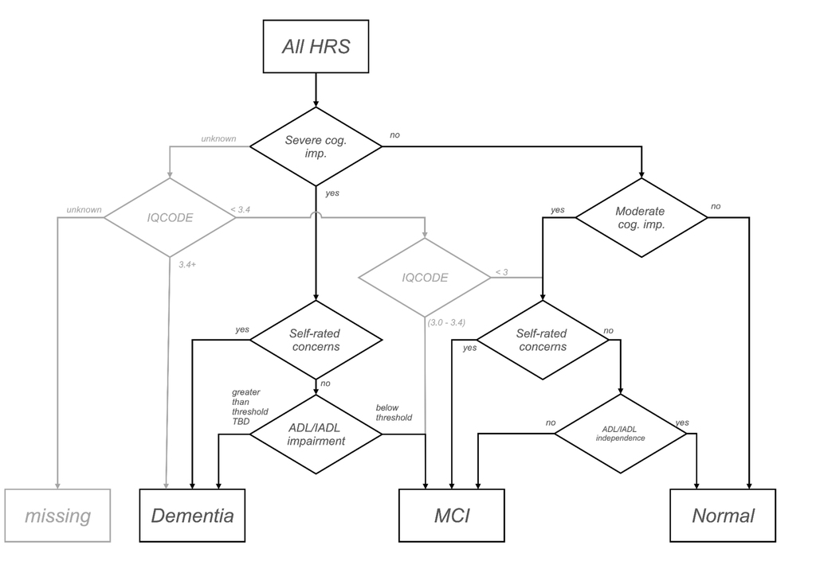

## PMM: final model

[figure not shown]

`cg` is the cognitive class (Normal, MCI, Dementia). In calibration it is fixed to the HRS/HCAP Algorithm class.

`K` holds the fixed coefficients from the robust norms group. They adjust the nine cognitive tests for demographics. They do not predict class.

Two models: a cognition and function model for people with cognitive tests, and an informant model (Jorm IQCODE and ADL/IADL items) for people without them.

The final model has no latent cognition factor. Each test is a direct indicator of class, which gave better agreement with the HRS/HCAP Algorithm.

## PMM: covariate adjustment

[figure not shown]

Each cognitive test on age, sex, race, ethnicity, education, and their interactions in the HRS/HCAP robust norms sample.

The regression coefficients describe expected test performance for a person free of conditions that affect cognition.

We save these coefficients and fix them in the PMM.

This step matches the norming step of the HRS/HCAP Algorithm.

## PMM: covariate adjustment

[figure not shown]

Three methods give the same adjustment: a residual from the norms-group equation, an offset, or fixed regression coefficients.

The HRS/HCAP Algorithm uses residuals. The PMM uses fixed coefficients, because five of the nine Core cognitive tests are ordinal (ordered categories), and residuals do not work for ordinal tests.

## PMM: class probabilities

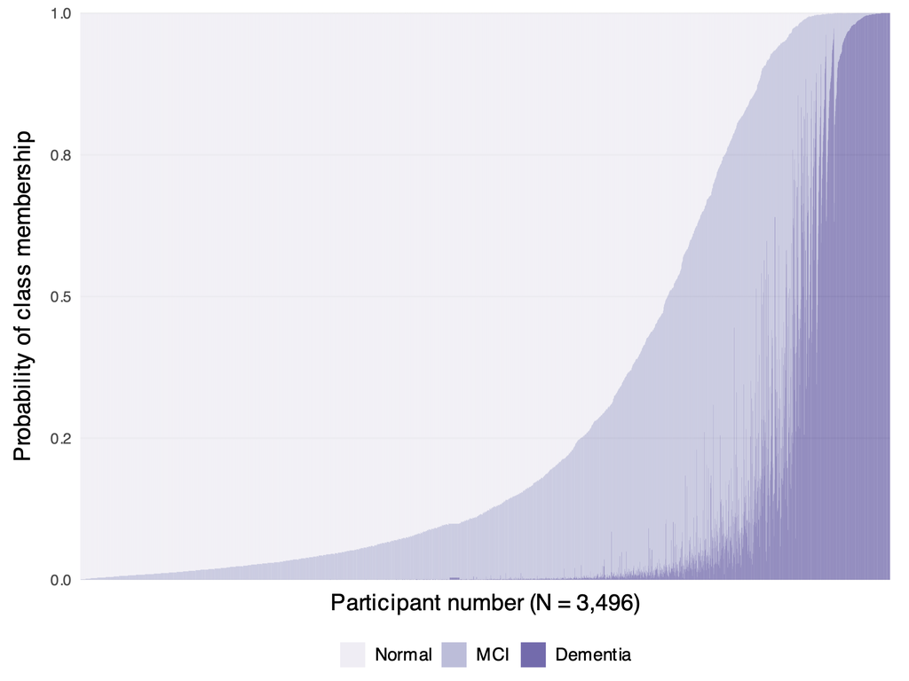

Each vertical bar is one HRS/HCAP participant, with the probabilities of Normal, MCI, and Dementia stacked. Participants are sorted by probability.

## Agreement with the HRS/HCAP Algorithm

| Compared with HRS/HCAP Algorithm | N | Normal, MCI, Dementia (weighted kappa) | Dementia vs. no dementia (kappa) |
| --- | --- | --- | --- |
| Core algorithm | 3,496 | 0.50 | 0.34 |
| PMM | 3,496 | 0.51 | 0.43 |

HRS/HCAP 2016 participants. Kappa measures agreement beyond chance (0 = chance, 1 = perfect). The three-class kappa uses quadratic weights, so a Normal vs. MCI disagreement counts less than a Normal vs. Dementia disagreement. All kappas use HCAP population weights (HCAP16WGTR). Both the Core algorithm and the PMM are calibrated and scored in the same sample, so its agreement is an in-sample estimate.

## Summary

- Both Core methods take their structure from the HRS/HCAP Algorithm: demographic adjustment set in a robust norms group, plus function, self-report, and informant data.
- Agreement with the HRS/HCAP Algorithm, three classes: Core algorithm 0.50; PMM 0.51.
- Agreement for dementia vs. no dementia: Core algorithm 0.34; PMM 0.43.
- CAUTION: these agreement statistics are in-sample (HRS/HCAP used for derivation and evaluation of the Core algorithms.)
- The PMM also gives each person a probability for each class, which carries classification uncertainty into later analyses.